# Multi-omics

Wednesday, September 30, 2026

## Multi-omics integration

- Integrate multiple omics layers: microbiome, metabolome, transcriptome, etc.
- Explore associations and predict outcomes
- Gain complementary insights that single-omics cannot provide

## Data containers

- `altExp()` slot in *TreeSummarizedExperiment*
- *MultiAssayExperiment*

## Methods

- **Association:** detect cross-omics correlations
- **Ordination:** reduce dimensionality, e.g., **MOFA2**, **Joint-RPCA**
- **Supervised machine learning:** predict outcomes, e.g., **IntegratedLearner**

## Cross-association

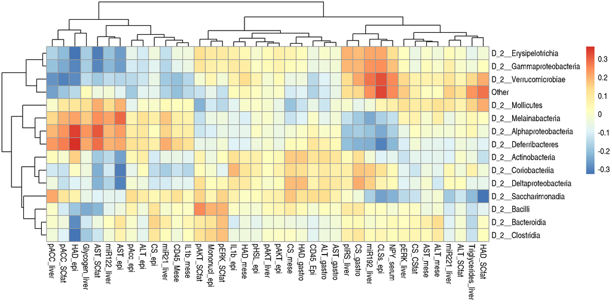

## Pearson correlation

- Measures linear association between two features
- Spearman correlation = Pearson correlation on ranks

$$r = \frac{
\underbrace{\sum_{i=1}^{n} (x_i - \bar{x})(y_i - \bar{y})}_{\text{numerator: covariance}}
}{
\underbrace{\sqrt{\sum_{i=1}^{n} (x_i - \bar{x})^2} \;\; \sqrt{\sum_{i=1}^{n} (y_i - \bar{y})^2}}_{\text{denominator: product of standard deviations}}
}$$

## Calculating “targeted” correlations

- Focus on feature pairs with found relationships
- Avoids computing all pairwise correlations
- Implemented in anansi (Bastiaanssen, Quinn, and Cryan 2023)

➡️ [anansi slides](https://microbiome.github.io/outreach/anansi.html)

[figure not shown]

## Ordination

*Multi-omics Factor Analysis (MOFA2)*

- Factorizes multi-omics matrix into latent factors
- Captures shared and data-specific variation across omics
- Outputs low-dimensional embeddings for samples and features

## Ordination

*Joint robust PCA (Joint-RPCA)* (Cordazzo Vargas et al. 2026)

- Shared sample space across any number of omics, with feature loadings per omic
- Robust clr and matrix completion handle sparse, compositional data
- Cross-omic feature covariances for network analysis
- In mia: `getJointRPCA()`, `addJointRPCA()`

➡️ [Joint-RPCA overview slides](https://microbiome.github.io/outreach/jointrpca.html)

## Classical multi-table methods

- **Mantel test, RV coefficient, co-inertia:** are two tables associated?
- **Sparse CCA:** which features drive the association?
- **STATIS, multiple factor analysis:** combine more than two tables
- **DPCoA:** use the phylogenetic tree as prior knowledge

➡️ [Multi-table methods slides](https://microbiome.github.io/outreach/multitable.html)

## Supervised ML

*IntegratedLearner*

- Predict phenotypes from multiple omics
- Ensemble learning combining base learners per omics

➡️ [IntegratedLearner slides](https://microbiome.github.io/outreach/integratedlearner.html)

## Demonstration

```r
library(mia)
library(pheatmap)

# Calculate correlations
mat <- getCrossAssociation(
  mae, assay.type1 = "rclr", experiment2 = 3,
  assay.type2 = "signals", mode = "matrix"
)
```

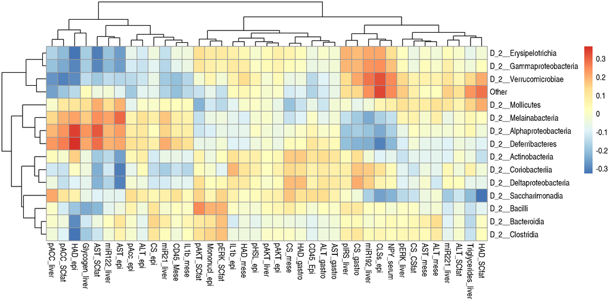

```r
library(mia)
library(pheatmap)

# Calculate correlations
mat <- getCrossAssociation(
  mae, assay.type1 = "rclr", experiment2 = 3,
  assay.type2 = "signals", mode = "matrix"
)
# Visualize
pheatmap(mat)
```

## Exercises

[From OMA online book, Chapter 23: Cross-association](https://microbiome.github.io/OMA/docs/devel/pages/cross_correlation.html)

- All exercises

## References

## Time series

A brief demonstration on time series tools.

- [miaTime](https://microbiome.github.io/miaTime/reference/index.html)
- [miaSim](https://microbiome.github.io/miaSim/reference/index.html)
- [miaViz](https://microbiome.github.io/miaViz/reference/index.html)

## MultiAssayExperiment for multi-omic data integration

The *MultiAssayExperiment* (*MAE*) mechanism facilitates the incorporation of multiple omics (e.g. taxonomic and functional profiling).

| Option | Rows (features) | Cols (samples) | Recommendation |
| --- | --- | --- | --- |
| assays | match | match | Data transformations |
| altExp | free | match | Alternative experiments |
| **MultiAssay** | free | free (mapping) | Multi-omic experiments |

## MultiAssayExperiment example data

Load example data set and list the available experiments:

```r
library(mia)
data(HintikkaXOData)
mae <- HintikkaXOData
experiments(mae)
```

```
ExperimentList class object of length 3:
 [1] microbiota: TreeSummarizedExperiment with 12706 rows and 40 columns
 [2] metabolites: TreeSummarizedExperiment with 38 rows and 40 columns
 [3] biomarkers: TreeSummarizedExperiment with 39 rows and 40 columns
```

## MultiAssayExperiment example data

Each element in a MultiAssayExperiment is a (Tree)SummarizedExperiment.

```r
experiments(mae)[["microbiota"]]
```

```
class: TreeSummarizedExperiment
dim: 12706 40
metadata(0):
assays(1): counts
rownames(12706): GAYR01026362.62.2014 CVJT01000011.50.2173 ...
  JRJTB:03787:02429 JRJTB:03787:02478
rowData names(7): Phylum Class ... Species OTU
colnames(40): C1 C2 ... C39 C40
colData names(0):
reducedDimNames(0):
mainExpName: NULL
altExpNames(0):
rowLinks: NULL
rowTree: NULL
colLinks: NULL
colTree: NULL
```

## MultiAssayExperiment example data

Each element in a MultiAssayExperiment is a (Tree)SummarizedExperiment.

```r
experiments(mae)[["metabolites"]]
```

```
class: TreeSummarizedExperiment
dim: 38 40
metadata(0):
assays(1): nmr
rownames(38): Butyrate Acetate ... Malonate 1,3-dihydroxyacetone
rowData names(0):
colnames(40): C1 C2 ... C39 C40
colData names(0):
reducedDimNames(0):
mainExpName: NULL
altExpNames(0):
rowLinks: NULL
rowTree: NULL
colLinks: NULL
colTree: NULL
```

## MultiAssayExperiment example data

Each element in a MultiAssayExperiment is a (Tree)SummarizedExperiment.

```r
experiments(mae)[["biomarkers"]]
```

```
class: TreeSummarizedExperiment
dim: 39 40
metadata(0):
assays(1): signals
rownames(39): Triglycerides_liver CLSs_epi ... NPY_serum Glycogen_liver
rowData names(0):
colnames(40): C1 C2 ... C39 C40
colData names(0):
reducedDimNames(0):
mainExpName: NULL
altExpNames(0):
rowLinks: NULL
rowTree: NULL
colLinks: NULL
colTree: NULL
```

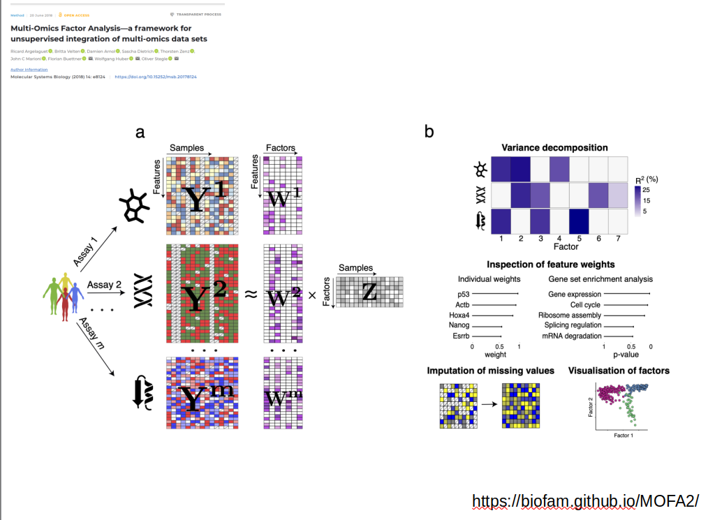

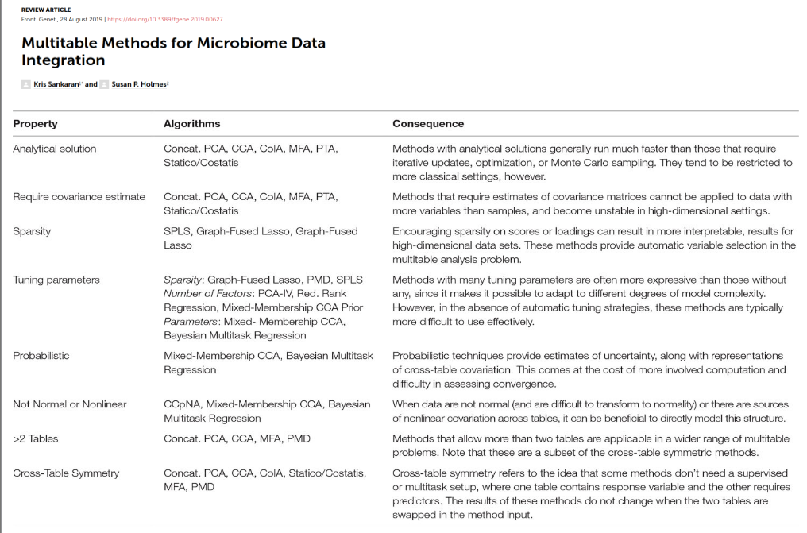

## Machine learning (Random Forests)

- You can always run any ML or other analysis method available in R by just extracting individual components from TreeSE (abundance assays and sample metadata)
- For important methods, the R/Bioconductor developer community tends to come up with more integrated solutions
- The development work always benefits from feedback

[figure not shown]

# Summary

## What this course was all about?

The scope of this course:

- **Brief introduction to *microbiome data science*** and some of its latest methods

This was *not* intended as a course in community ecology or machine learning in general.

## Learning goals

- microbiome data science with R/Bioconductor, a popular open-source environment for life science informatics
- key concepts in microbiome bioinformatics
- open & reproducible data science workflow

After the course you will know how to approach new tasks in the analysis of taxonomic profiling data by taking advantage of available documentation and R tools.

[figure not shown]

Moreno-Indias et al. (2021) Statistical and Machine Learning Techniques in Human Microbiome Studies: Contemporary Challenges and Solutions. Frontiers in Microbiology.

## Workflow

[figure not shown]

Domenick Braccia, EuroBioc 2020 (microbiome.github.io)

**These slides have been generated with Quarto**

## Overview of the week

**Day 1** Basic data wrangling

**Day 2** Assays, transformations & alpha diversity

**Day 3** Aggregating and splitting data; beta diversity

**Day 4** DA analysis, heatmaps, time series, multi-omics integration

[figure not shown]

## Where to find more information and examples?

[OMA online book](https://microbiome.github.io/OMA) (beta version!)

Function references and vignettes in individual packages:

- [mia](https://microbiome.github.io/mia/reference/index.html): basic manipulation
- [miaViz](https://microbiome.github.io/miaViz/reference/index.html): visualization
- [miaTime](https://microbiome.github.io/miaTime/reference/index.html): time series
- [miaSim](https://microbiome.github.io/miaSim/reference/index.html): simulation
- [philr](http://bioconductor.org/packages/devel/bioc/html/philr.html): phylogenetic balances (Silverman et al)
- [ANCOMBC](https://bioconductor.org/packages/devel/bioc/vignettes/ANCOMBC/inst/doc/ANCOMBC.html) (Lin & Peddada)
- [curatedMetagenomicData](https://waldronlab.io/curatedMetagenomicData/); (Pasolli et al.) human demo data
- [microbiomeDataSets](https://microbiome.github.io/microbiomeDataSets/index.html); other demo data
- SingleCell tool family
- SE tool family
- …

## Join the community

Support the development and documentation by actively providing feedback & suggestions.

- Online support chat (Gitter) https://gitter.im/microbiome/miaverse
- [Bioconductor Slack](https://bioc-community.herokuapp.com/) (#miaverse channel)
- Mailing list (see microbiome.github.io)
- Github issues (e.g. [OMA issues](https://github.com/microbiome/OMA/issues))

## Thanks!

- All participants!
- Organizer: Finnish IT Center for Science (CSC)
- Developers:
  - Leo Lahti, Assoc. Prof.
  - Tuomas Borman, PhD researcher
  - Chouaib Benchraka, Scientific programmer
  - For a full list of key developers and contributors, see [OMA acknowledgments](https://microbiome.github.io/OMA/acknowledgments.html)

Department of Computing, University of Turku, Finland datascience.utu.fi

## Feedback

- CSC will send a feedback form

## Q & A session

Bastiaanssen, Thomaz F S, Thomas P Quinn, and John F Cryan. 2023. “Knowledge-Based Integration of Multi-Omic Datasets with Anansi: Annotation-Based Analysis of Specific Interactions.” *arXiv*. https://doi.org/10.48550/arXiv.2305.10832.

Cordazzo Vargas, Bianca, Cameron Martino, Amanda Hazel Dilmore, Jessica Metcalf, Zachary Burcham, Leo Lahti, Aituar Bektanov, et al. 2026. “Joint-RPCA: Domain-Aware Multi-Omics Integration for Systems Microbiology.” *Molecular Systems Biology*. https://doi.org/10.1038/s44320-026-00236-3.